# Jaccard Index

Zuguang Gu (z.gu@dkfz.de)

2020-07-07

Following two consensus heatmaps (Figure S3.1) are for $k$ = 2 and 3 (2 and 3 groups) on GDS1875 GDS dataset under top-value method **ATC** and partitioning method **hclust** (cola report is [here](https://cola-gds.github.io/GDS1875/cola_report.html)). Figure S3.1 illustrates that when the number of subgroups increases form 2 to 3, a tiny subgroup only with one single sample is separated from one of the big subgroups.

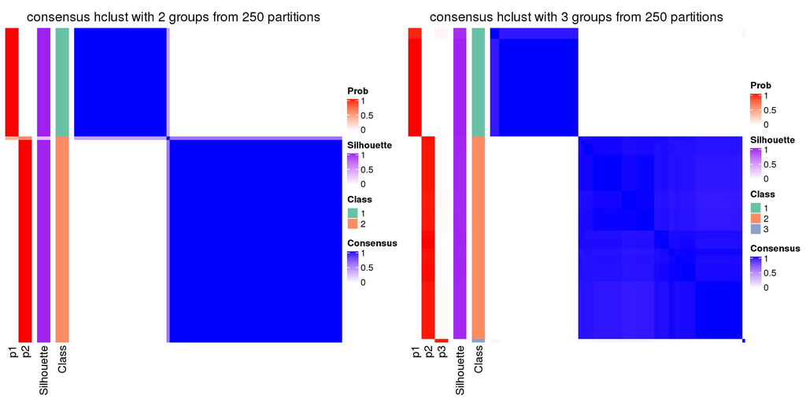

Figure S3.1. Consensus heatmaps for k = 2 and 3.

Next we plot the 1-PAC scores as well Jaccard indices for the partitions under each $k$ (Figure S3.2). We can see the 1-PAC scores are both very high at $k$ = 2 and 3, which means the partitions are both very stable for the two $k$. However, the Jaccard index is extremely high at $k$ = 3 (0.97), which quantitatively shows partitions in $k$ = 3 is highly similar as $k$ = 2, and on the other hand, an extra subgroup only with one single sample does not provide any useful output for the analysis. Thus, we decline $k$ = 3 is a better choice while still take $k$ = 2 as the best number of subgroups.

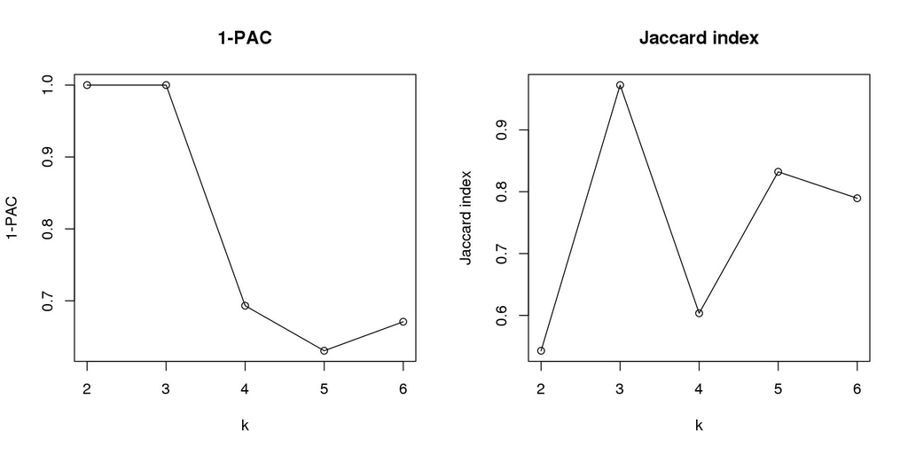

Figure S3.2. The 1-PAC scores as well as Jaccard indices for the partitions under each k.